# LUT Analysis

Yuyang Zhao

# Motivation

Given a LUT that represents some mapping $f:\mathbb{R}^3\to\mathbb{R}^3$, I want to analyze some of its properties. One idea is to represent the LUT in some 2 dimensional plot. Some ways to do this include projecting all the (r,g,b) vectors onto some plane, or examining a cross-section plane of the LUT. The former method represents all data points, which is too much information at a time, while the latter will likely represent too little information at a time.

To get the best of both worlds, I will take a slice of the LUT bounded by two parallel planes and project this slice onto a 2D plot. I can setup the orientation of the slice by defining a normal vector $\vec{n}$ orthogonal to a plane $P$ crossing the origin. I can define the slice itself by translating $P$ along $P^\perp=\{t\vec{n}:t\in\mathbb{R}\}$ to get two new planes that bound the slice. Finally I can setup the location of the slice by translating these two planes by some vector in space.

# Implementation

```r
rm(list=ls())
vector_dot <- function(x, y) {
  return(sum(x * y))
}
vector_norm <- function(x) {
  return(sqrt(vector_dot(x, x)))
}
vector_proj_fn <- function(n) {
  return(function(x) {
    return(vector_dot(x, n)/vector_dot(n, n) * n)
  })
}
vector_perp_fn <- function(n) {
  return(function(x) {
    return(x - vector_proj_fn(n)(x))
  })
}
cross_product <- function(x, y) {
  v1 <- x[2] * y[3] - x[3] * y[2]
  v2 <- x[3] * y[1] - x[1] * y[3]
  v3 <- x[1] * y[2] - x[2] * y[1]
  return(c(v1, v2, v3))
}
```

Let’s first implement a special case where I’m not interested in relocating the slice. Notice that the slice is bounded by 2 planes orthogonal to $\vec{n}$. Thus a point $\vec{v}$ lies in the slice if $proj_n(\vec{v})$ lies in the slice.

```r
slice_perp_to_n_fn <- function(n) {
  proj_n <- vector_proj_fn(n)
  return(function(data, bounds) {
    mapply(FUN=function(x, y, z) {
      v <- proj_n(c(x, y, z))
      norm_v <- vector_norm(v)
      return(bounds[1] <= norm_v && norm_v <= bounds[2])
    }, data[,1], data[,2], data[,3])
  })
}
```

Later we will set $\vec{n}:=(1,1,1)$ which is an interesting normal vector because
$$proj_{(1,1,1)}(r,g,b)
=\frac{r+g+b}{3}\begin{bmatrix}1\\1\\1\end{bmatrix}
=\begin{bmatrix}\bar{v}\\\bar{v}\\\bar{v}\end{bmatrix},\ \bar{v}=mean(r,g,b)$$
Thus each component of the projection become the arithmetic mean of (r,g,b) i.e the brightness. We’ll essentially find all the points that lie in a certain brightness range bounded by **bounds**.

If our RGB data was transformed into HSL data, then we can define a similar slice perpendicular to the lightness axis, which is similar to but not the same as brightness.

```r
slice_perp_to_lightness <- function(hsl_data, bounds) {
  bounds[1] <= hsl_data[,3] & hsl_data[,3] <= bounds[2]
}
```

Next I will define a new projection transformation that “flattens” our slice into the plane $P$ orthogonal to $\vec{n}$. It’s easier to define this as a diagonal matrix $D$ in terms of some basis for $P$. We’ll use a change of basis matrix $R$ to apply the transformation. To preserve angles, we want $R$ to be a rotation matrix. A natural choice for $R$ would be the matrix that rotates $\hat{n}$ to $\vec{e_3}=(0,0,1)$. This [*source*](https://math.stackexchange.com/questions/180418/calculate-rotation-matrix-to-align-vector-a-to-vector-b-in-3d) helps us find such a matrix.

```r
rotate_matrix <- function(D, a, b) {
  I <- cbind(c(1,0,0), c(0,1,0), c(0,0,1))
  a_hat <- a / vector_norm(a)
  b_hat <- b / vector_norm(b)
  v <- cross_product(a_hat, b_hat)
  c <- vector_dot(a_hat, b_hat)
  v_cross <- rbind(
    c(0, -v[3], v[2]),
    c(v[3], 0, -v[1]),
    c(-v[2], v[1], 0)
  )
  R <- I + v_cross + v_cross %*% v_cross / (1 + c)
  return(D %*% R)
}
```

Now we can define a plotting function that plots some desired brightness range of RGB data. For comparison, I will also define a plotting function that plots some desired lightness range of HSL data. We can define a helper function to transform RGB data to HSL data using this [*source*](https://en.wikipedia.org/wiki/HSL_and_HSV).

```r
rgb_to_hsl <- function(lut) {
  t(apply(lut, MARGIN=1, FUN=function(rgb_vec) {
    M <- max(rgb_vec)
    m <- min(rgb_vec)
    C <- M - m
    if (C == 0) {
      return(c(0, 0, 0))
    }
    r <- rgb_vec[1]
    g <- rgb_vec[2]
    b <- rgb_vec[3]
    if (M == r) {
      H <- (g - b) / C %% 6
    } else if (M == g) {
      H <- (b - r) / C + 2
    } else if (M == b) {
      H <- (r - g) / C + 4
    }
    H <- 60 * H * pi / 180
    if (H < 0) {
      H <- 2 * pi + H
    }
    L <- (M + m) / 2
    if (L == 1 || L == 0) {
      S <- 0
    } else {
      S <- C / (1 - abs(2 * L - 1))
    }
    return(c(H, S, L))
  }))
}
plot_slice_perp_to_brightness <- function(lut, pos, thickness, pointSize=1) {
  n <- c(1, 1, 1)
  norm_n <- vector_norm(n)
  slice_perp_to_brightness <- slice_perp_to_n_fn(n)

  bounds <- c(pos-thickness, pos+thickness) * norm_n
  slice <- lut[slice_perp_to_brightness(lut, bounds),]

  D <- cbind(c(1,0,0), c(0,1,0), c(0,0,0))
  A <- rotate_matrix(D, n, c(0,0,1))

  slice_flattened <- mapply(FUN=function(r, g, b) {A %*% c(r, g, b)}, slice$r, slice$b, slice$g)
  slice_flattened <- matrix(slice_flattened, ncol=3, byrow=TRUE)

  colouring <- mapply(FUN=function(r, g, b) {
    colour_range <- 0.8
    colour <- colour_range * c(r, g, b)
    return(rgb(colour[1], colour[2], colour[3]))
  }, slice$r, slice$g, slice$b)
  plot(slice_flattened[,1], slice_flattened[,2],
       main="RGB Slice", xlim=c(-1, 1), ylim=c(-1, 1), asp=1, col=colouring, pch=20, cex=pointSize)
  text(-0.9, -0.9, paste("brightness: ", round(pos, digits=2)))
}
plot_slice_perp_to_lightness <- function(lut, pos, thickness, pointSize=1) {
  hsl_lut <- rgb_to_hsl(lut)
  bounds <- c(pos-thickness, pos+thickness)
  slice_hsl <- hsl_lut[slice_perp_to_lightness(hsl_lut, bounds),]

  colour_range <- 0.8
  slice_rgb <- colour_range * lut[slice_perp_to_lightness(hsl_lut, bounds),]
  colouring <- mapply(FUN=rgb, slice_rgb[,1], slice_rgb[,2], slice_rgb[,3])
  if (length(slice_hsl) == 0) {
    slice_xyz <- cbind(c(), c(), c())
  } else {
    slice_xyz <- t(apply(slice_hsl, MAR=1, FUN=function(hsl_vec) {
      x <- hsl_vec[2] * cos(hsl_vec[1])
      y <- hsl_vec[2] * sin(hsl_vec[1])
      z <- hsl_vec[3]
      return(c(x, y, z))
    }))
  }
  plot(slice_xyz[,1], slice_xyz[,2],
       main="HSL Slice", xlim=c(-1, 1), ylim=c(-1, 1), asp=1, col=colouring, pch=20, cex=pointSize)
  text(-0.9, -0.9, paste("lightness: ", round(pos, digits=2)))
}
```

We now load some LUTs and play.

```r
k5207_neg_lut <- read.csv("slog3cine-k5207.cube",
                            sep=" ", header=FALSE, skip=5, col.names=c("r", "g", "b"))
k5207_print_lut <- read.csv("slog3cine-k5207-print.cube",
                            sep=" ", header=FALSE, skip=5, col.names=c("r", "g", "b"))
d <- seq(0, 1, length.out=33)
identity_lut <- Reduce(f=function(m, r) {
  gb_plane <- Reduce(f=function(m, g) {
    b_line <- Reduce(f=function(m, b) {
      return(rbind(m, c(r, g, b)))
    }, d, init=matrix(, nrow=0, ncol=3))
    return(rbind(m, b_line))
  }, d, init=matrix(, nrow=0, ncol=3))
  return(rbind(m, gb_plane))
}, d, init=matrix(, nrow=0, ncol=3))
identity_lut <- data.frame(r=identity_lut[,1], g=identity_lut[,2], b=identity_lut[,3])
#lut <- k5207_print_lut
#lut <- k5207_print_lut[sample(nrow(k5207_print_lut), 20000),]
lut <- identity_lut
hsl_lut <- rgb_to_hsl(lut)
```

## Respective colour curves: brightness, lightness, red, blue, green

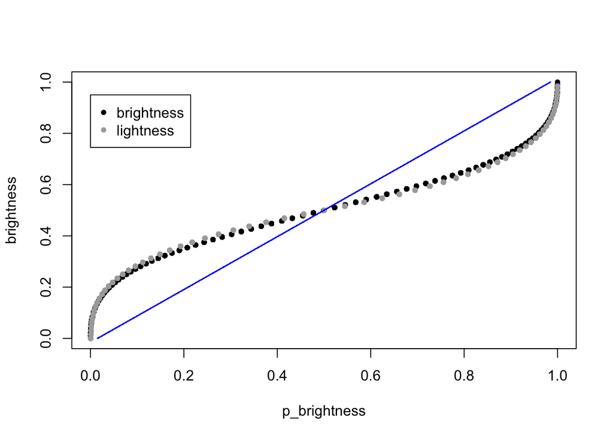

```r
brightness <- apply(lut, MAR=1, FUN=mean)
p_brightness <- rank(brightness) / length(brightness)

lightness <- hsl_lut[,3]
p_lightness <- rank(lightness) / length(lightness)

reds <- lut$r
p_reds <- rank(reds) / length(reds)
greens <- lut$g
p_greens <- rank(greens) / length(greens)
blues <- lut$b
p_blues <- rank(blues) / length(blues)

plot(p_brightness, brightness, pch=20)
points(p_lightness, lightness, col="darkgray", pch=20)
lines(p_reds, reds, col="red")
lines(p_greens, greens, col="green")
lines(p_blues, blues, col="blue")
legend(0, 0.95, legend=c("brightness", "lightness"), col=c("black", "darkgray"), pch=20)
```

## Cross-sections

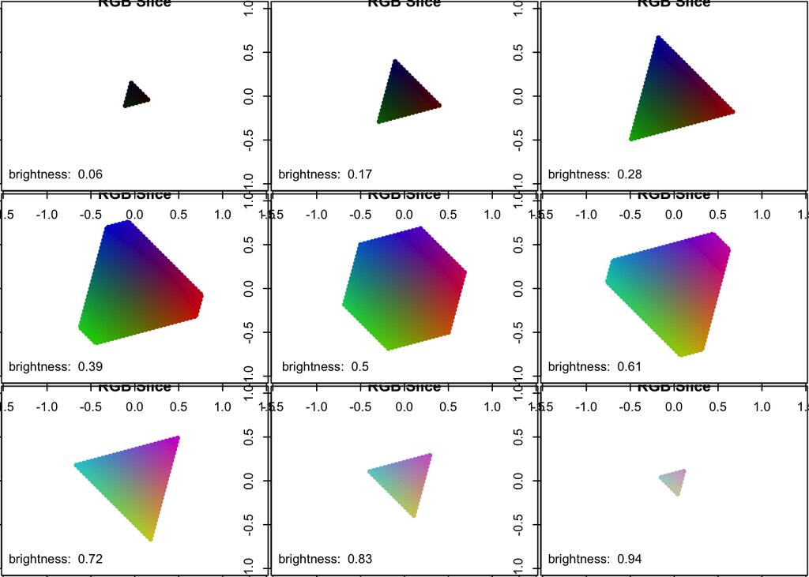

```r
par(mfrow=c(3, 3), mar=rep(0.1, 4))
# Build images -> save them at .png format
#png(file="slice%02d.png", width=640, height=640)
num_images <- 9
offset <- ceiling(num_images / 2) - num_images / 2
for (i in c(1:num_images)) {
  t <- (offset + i - 1) / num_images
  plot_slice_perp_to_brightness(lut, t, 0.01)
}
```

```r
# Use image magick
#system("convert -delay 12 *.png slices.gif")

# Remove png files
#file.remove(list.files(pattern=".png"))
```

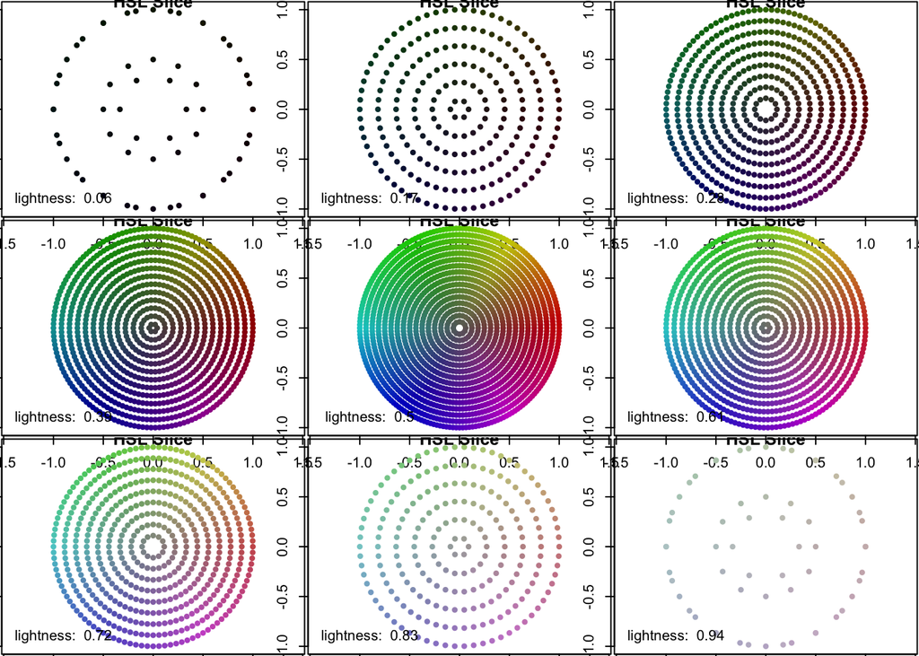

```r
par(mfrow=c(3, 3), mar=rep(0.1, 4))
# Build images -> save them at .png format
#png(file="slice%02d.png", width=640, height=640)
num_images <- 9
offset <- ceiling(num_images / 2) - num_images / 2
for (i in c(1:num_images)) {
  t <- (offset + i - 1) / num_images
  plot_slice_perp_to_lightness(lut, t, 0.01)
}
```

```r
# Use image magick
#system("convert -delay 12 *.png slices.gif")

# Remove png files
#file.remove(list.files(pattern=".png"))
```